# Caractéristiques socio démographiques

## 2.3 type d’agriculture et niveau d’étude

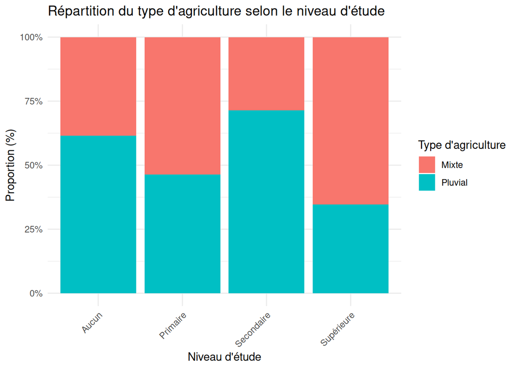

```
##
##  Fisher's Exact Test for Count Data with simulated p-value (based on
##  2000 replicates)
##
## data:  table_croise
## p-value = 0.1189
## alternative hypothesis: two.sided
```

# 3 Analyse factorielle avec les profils

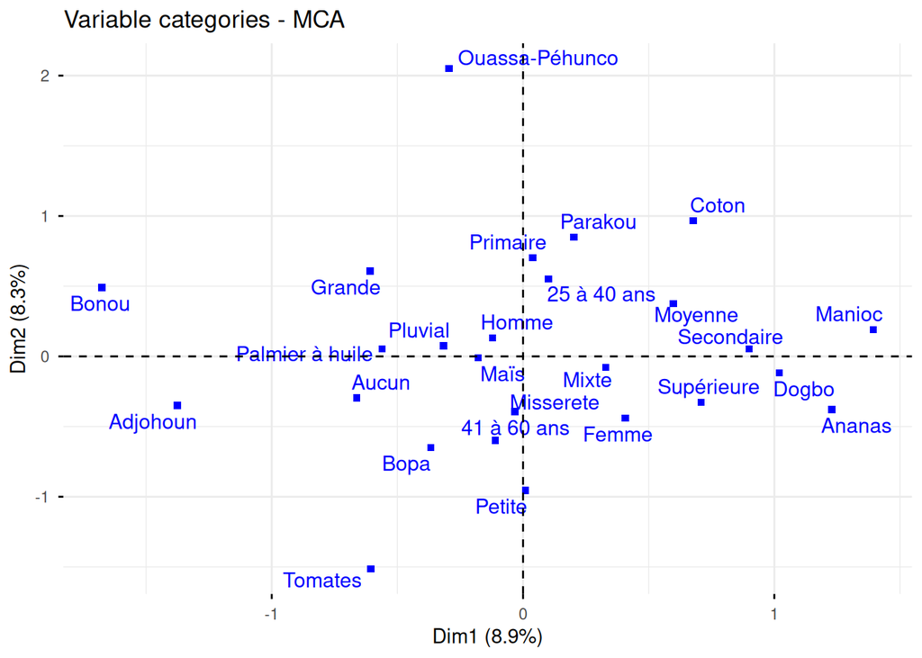

L’ACM montre une structuration de l’espace de production selon le profil socio-économique. Le segment A (Haut-Droite) Profil : Jeunes (25-40 ans), niveau secondaire, superficies moyennes.

Le segment C (Gauche) Profil : Pas d’instruction, grandes surfaces de palmier/tomates ou agriculture pluviale.

# 4 Conclusion partielle

L’analyse statistique, bien que révélant une certaine homogénéité des pratiques à travers les tests de Fisher, souligne par l’ACM une structuration de l’espace agricole où le capital scolaire commence à orienter les choix techniques. Cette absence de clivages rigides prouve que les systèmes de production ne sont pas dictés par la fatalité du profil social, mais restent ouverts à une transformation par l’outil numérique. Dès lors, la solution proposée doit être universelle dans ses fonctions mais inclusive dans son ergonomie, afin de convertir ces tendances latentes en une adoption généralisée des meilleures pratiques agricoles.